# 数据科学的编程工具

# Python使用简介

王成军

wangchengjun@nju.edu.cn

计算传播网 http://computational-communication.com

# 人生苦短，我用Python。

Python（/ˈpaɪθən/）是一种面向对象、解释型计算机程序设计语言

- 由Guido van Rossum于1989年底发明
- 第一个公开发行版发行于1991年
- Python语法简洁而清晰
- 具有强大的标准库和丰富的第三方模块
- 它常被昵称为胶水语言
- TIOBE编程语言排行榜“2010年度编程语言”

# 特点

- 免费、功能强大、使用者众多
- 与R和MATLAB相比，Python是一门更易学、更严谨的程序设计语言。使用Python编写的脚本更易于理解和维护。
- 如同其它编程语言一样，Python语言的基础知识包括：类型、列表（list）和元组（tuple）、字典（dictionary）、条件、循环、异常处理等。
- 关于这些，初阶读者可以阅读《Beginning Python》一书（Hetland, 2005)。

## Python中包含了丰富的类库。

众多开源的科学计算软件包都提供了Python的调用接口，例如著名的计算机视觉库OpenCV。 Python本身的科学计算类库发展也十分完善，例如NumPy、SciPy和matplotlib等。 就社会网络分析而言，igraph, networkx, graph-tool, Snap.py等类库提供了丰富的网络分析工具

## Python软件与IDE

目前最新的Python版本为3.0，更稳定的2.7版本。 编译器是编写程序的重要工具。 免费的Python编译器有Spyder、PyCharm(免费社区版)、Ipython、Vim、 Emacs、 Eclipse(加上PyDev插件)。

# Installing Anaconda Python

- Use the Anaconda Python
  - http://continuum.io/downloads.html

# 第三方包可以使用pip install的方法安装。

- 可以点击ToolsOpen command prompt
- 然后在打开的命令窗口中输入：
  - pip install beautifulsoup4

> pip install beautifulsoup4
- NumPy /SciPy for scientific computing
- pandas to make Python usable for data analysis
- matplotlib to make graphics
- scikit-learn for machine learning

```python
%matplotlib inline
import random, datetime
import numpy as np
import matplotlib.pyplot as plt
import matplotlib
import statsmodels.api as sm
from scipy.stats import norm
from scipy.stats.stats import pearsonr
```

# Variable Type

```python
# str, int, float
str(3)
```

```
'3'
```

```python
"chengjun wang"
```

```
'chengjun wang'
```

```python
# int
int('5')
```

```
5
```

```python
# float
float('7.1')
```

```
7.1
```

```python
range(10)
```

```
range(0, 10)
```

```python
# for i in range(1, 10):
#     print(i)

range(1,10)
```

```
range(1, 10)
```

# dir & help

当你想要了解对象的详细信息时使用

```python
dir
```

```
<function dir>
```

```python
dir(str)[-10:]
```

```
['rstrip',
 'split',
 'splitlines',
 'startswith',
 'strip',
 'swapcase',
 'title',
 'translate',
 'upper',
 'zfill']
```

```python
help(str)
```

```
Help on class str in module builtins:

class str(object)
 |  str(object='') -> str
 |  str(bytes_or_buffer[, encoding[, errors]]) -> str
 |  Create a new string object from the given object. If encoding or
 |  errors is specified, then the object must expose a data buffer
 |  that will be decoded using the given encoding and error handler.
 |  Otherwise, returns the result of object.__str__() (if defined)
 |  or repr(object).
 |  encoding defaults to sys.getdefaultencoding().
 |  errors defaults to 'strict'.
 |  Methods defined here:
 |  __add__(self, value, /)
 |      Return self+value.
 |  __contains__(self, key, /)
 |      Return key in self.
 |  __eq__(self, value, /)
 |      Return self==value.
 |  __format__(...)
 |      S.__format__(format_spec) -> str
 |      Return a formatted version of S as described by format_spec.
 |  __ge__(self, value, /)
 |      Return self>=value.
 |  __getattribute__(self, name, /)
 |      Return getattr(self, name).
 |  __getitem__(self, key, /)
 |      Return self[key].
 |  __getnewargs__(...)
 |  __gt__(self, value, /)
 |      Return self>value.
 |  __hash__(self, /)
 |      Return hash(self).
 |  __iter__(self, /)
 |      Implement iter(self).
 |  __le__(self, value, /)
 |      Return self<=value.
 |  __len__(self, /)
 |      Return len(self).
 |  __lt__(self, value, /)
```

[output cut: 214 more lines]

```
 |  zfill(...)
 |      S.zfill(width) -> str
 |      Pad a numeric string S with zeros on the left, to fill a field
 |      of the specified width. The string S is never truncated.
 |  ----------------------------------------------------------------------
 |  Static methods defined here:
 |  maketrans(x, y=None, z=None, /)
 |      Return a translation table usable for str.translate().
 |      If there is only one argument, it must be a dictionary mapping Unicode
 |      ordinals (integers) or characters to Unicode ordinals, strings or None.
 |      Character keys will be then converted to ordinals.
 |      If there are two arguments, they must be strings of equal length, and
 |      in the resulting dictionary, each character in x will be mapped to the
 |      character at the same position in y. If there is a third argument, it
 |      must be a string, whose characters will be mapped to None in the result.
```

```python
x = ' Hello WorlD  '
dir(x)[-10:]
```

```
['rstrip',
 'split',
 'splitlines',
 'startswith',
 'strip',
 'swapcase',
 'title',
 'translate',
 'upper',
 'zfill']
```

```python
# lower
x.lower()
```

```
' hello world  '
```

```python
# upper
x.upper()
```

```
' HELLO WORLD  '
```

```python
# rstrip
x.rstrip()
```

```
' Hello WorlD'
```

```python
# strip
x.strip()
```

```
'Hello WorlD'
```

```python
# replace
x.replace('lo', '')
```

```
' Hel WorlD  '
```

```python
# split
x.split('lo')
```

```
[' Hel', ' WorlD  ']
```

```python
# join
','.join(['a', 'b'])
```

```
'a,b'
```

# type

当你想要了解变量类型时使用type

```python
x = 'hello world'
type(x)
```

```
str
```

# Data Structure

list, tuple, set, dictionary, array

```python
l = [1,2,3,3] # list
t = (1, 2, 3, 3) # tuple
s = set([1,2,3,3]) # set
d = {'a':1,'b':2,'c':3} # dict
a = np.array(l) # array
print(l, t, s, d, a)
```

```
[1, 2, 3, 3] (1, 2, 3, 3) {1, 2, 3} {'b': 2, 'a': 1, 'c': 3} [1 2 3 3]
```

```python
l = [1,2,3,3] # list
l.append(4)
l
```

```
[1, 2, 3, 3, 4]
```

```python
d = {'a':1,'b':2,'c':3} # dict
d.keys()
```

```
dict_keys(['c', 'a', 'b'])
```

```python
d = {'a':1,'b':2,'c':3} # dict
d.values()
```

```
dict_values([3, 1, 2])
```

```python
d = {'a':1,'b':2,'c':3} # dict
d['b']
```

```
2
```

```python
d = {'a':1,'b':2,'c':3} # dict
d.items()
```

```
dict_items([('c', 3), ('a', 1), ('b', 2)])
```

# 定义函数

```python
def devidePlus(m, n): # 结尾是冒号
    y = m/n + 1 # 注意：空格
    return y          # 注意：return
```

## For 循环

```python
range(10)
```

```
range(0, 10)
```

```python
range(1, 10)
```

```
range(1, 10)
```

```python
for i in range(10):
    print(i, i*10, i**2)
```

```
0 0 0
1 10 1
2 20 4
3 30 9
4 40 16
5 50 25
6 60 36
7 70 49
8 80 64
9 90 81
```

```python
for i in range(10):
    print(i*10)
```

```
0
10
20
30
40
50
60
70
80
90
```

```python
for i in range(10):
    print(devidePlus(i, 2))
```

```
1.0
1.5
2.0
2.5
3.0
3.5
4.0
4.5
5.0
5.5
```

```python
# 列表内部的for循环
r = [devidePlus(i, 2)  for i in range(10)]
r
```

```
[1.0, 1.5, 2.0, 2.5, 3.0, 3.5, 4.0, 4.5, 5.0, 5.5]
```

# map

```python
m1 = map(devidePlus, [4,3,2], [2, 1, 5])
print(*m1)
#print(*map(devidePlus, [4,3,2], [2, 1, 5]))
# 注意： 将（4， 2)作为一个组合进行计算，将（3， 1）作为一个组合进行计算
```

```
3.0 4.0 1.4
```

```python
m2 = map(lambda x, y: x + y, [1, 3, 5, 7, 9], [2, 4, 6, 8, 10])
print(*m2)
```

```
3 7 11 15 19
```

```python
m3 = map(lambda x, y, z: x + y - z, [1, 3, 5, 7, 9], [2, 4, 6, 8, 10], [3, 3, 2, 2, 5])
print(*m3)
```

```
0 4 9 13 14
```

# if elif else

```python
j = 5
if j%2 == 1:
    print(r'余数是1')
elif j%2 ==0:
    print(r'余数是0')
else:
    print(r'余数既不是1也不是0')
```

```
余数是1
```

```python
x = 5
if x < 5:
    y = -1
    z = 5
elif x > 5:
    y = 1
    z = 11
else:
    y = 0
    z = 10
print(x, y, z)
```

```
5 0 10
```

# while循环

```python
j = 0
while j <10:
    print(j)
    j+=1 # avoid dead loop
```

```
0
1
2
3
4
5
6
7
8
9
```

```python
j = 0
while j <10:
    if j%2 != 0:
        print(j**2)
    j+=1 # avoid dead loop
```

```
1
9
25
49
81
```

```python
j = 0
while j <50:
    if j == 30:
        break
    if j%2 != 0:
        print(j**2)
    j+=1 # avoid dead loop
```

```
1
9
25
49
81
121
169
225
289
361
441
529
625
729
841
```

```python
a = 4
while a: # 0, None, False
    print(a)
    a -= 1
    if a < 0:
        a = None # []
```

```
4
3
2
1
```

# try except

```python
def devidePlus(m, n): # 结尾是冒号
    return m/n+ 1 # 注意：空格


for i in [2, 0, 5]:
    try:
        print(devidePlus(4, i))
    except Exception as e:
        print(e)
        pass
```

```
3.0
division by zero
1.8
```

```python
alist = [[1,1], [0, 0, 1]]
for aa in alist:
    try:
        for a in aa:
            print(10 / a)
    except Exception as e:
        print(e)
        pass
```

```
10.0
10.0
division by zero
```

```python
alist = [[1,1], [0, 0, 1]]
for aa in alist:
    for a in aa:
        try:
            print(10 / a)
        except Exception as e:
            print(e)
            pass
```

```
10.0
10.0
division by zero
division by zero
10.0
```

# Write and Read data

```python
data =[[i, i**2, i**3] for i in range(10)]
data
```

```
[[0, 0, 0],
 [1, 1, 1],
 [2, 4, 8],
 [3, 9, 27],
 [4, 16, 64],
 [5, 25, 125],
 [6, 36, 216],
 [7, 49, 343],
 [8, 64, 512],
 [9, 81, 729]]
```

```python
for i in data:
    print('\t'.join(map(str, i)))
```

```
0	0	0
1	1	1
2	4	8
3	9	27
4	16	64
5	25	125
6	36	216
7	49	343
8	64	512
9	81	729
```

```python
type(data)
```

```
list
```

```python
len(data)
```

```
10
```

```python
data[0]
```

```
[0, 0, 0]
```

```python
help(f.write)
```

```
Help on built-in function write:

write(...)
    write(str) -> None.  Write string str to file.

    Note that due to buffering, flush() or close() may be needed before
    the file on disk reflects the data written.
```

```python
# 保存数据
data =[[i, i**2, i**3] for i in range(10000)]

f = open("../data/data_write_to_file.txt", "w")
for i in data:
    f.write('\t'.join(map(str,i)) + '\n')
f.close()
```

```python
with open('../data/data_write_to_file.txt','r') as f:
    data = f.readlines()
data[:5]
```

```
['0\t0\t0\n', '1\t1\t1\n', '2\t4\t8\n', '3\t9\t27\n', '4\t16\t64\n']
```

```python
with open('../data/data_write_to_file.txt','r') as f:
    data = f.readlines(1000)
len(data)
```

[output not shown]

```python
with open('../data/data_write_to_file.txt','r') as f:
    print(f.readline())
```

```
0	0	0
```

```python
f = [1, 2, 3, 4, 5]
for k, i in enumerate(f):
    print(k, i)
```

```
0 1
1 2
2 3
3 4
4 5
```

```python
with open('../data/data_write_to_file.txt','r') as f:
    for i in f:
        print(i)
```

```
0	0	0

1	1	1

2	4	8

3	9	27

4	16	64

5	25	125

6	36	216

7	49	343

8	64	512

9	81	729

10	100	1000

11	121	1331

12	144	1728

13	169	2197

14	196	2744

15	225	3375

16	256	4096

17	289	4913

18	324	5832

19	361	6859

```

[output cut: 19944 more lines]

```
9992	99840064	997601919488

9993	99860049	997901469657

9994	99880036	998201079784

9995	99900025	998500749875

9996	99920016	998800479936

9997	99940009	999100269973

9998	99960004	999400119992

9999	99980001	999700029999
```

```python
with open('../data/data_write_to_file.txt','r') as f:
    for k, i in enumerate(f):
        if k%2000 == 0:
            print(i)
```

```
0	0	0

2000	4000000	8000000000

4000	16000000	64000000000

6000	36000000	216000000000

8000	64000000	512000000000
```

```python
data = []
line = '0\t0\t0\n'
line = line.replace('\n', '')
line = line.split('\t')
line = [int(i) for i in line] # convert str to int
data.append(line)
data
```

```
[[0, 0, 0]]
```

```python
# 读取数据
data = []
with open('../data/data_write_to_file.txt','r') as f:
    for line in f:
#         line = line.replace('\n', '').split('\t')
#         line = [int(i) for i in line]
        data.append(line)
data
```

```
['0\t0\t0\n',
 '1\t1\t1\n',
 '2\t4\t8\n',
 '3\t9\t27\n',
 '4\t16\t64\n',
 '5\t25\t125\n',
 '6\t36\t216\n',
 '7\t49\t343\n',
 '8\t64\t512\n',
 '9\t81\t729\n',
 '10\t100\t1000\n',
 '11\t121\t1331\n',
 '12\t144\t1728\n',
 '13\t169\t2197\n',
 '14\t196\t2744\n',
 '15\t225\t3375\n',
 '16\t256\t4096\n',
 '17\t289\t4913\n',
 '18\t324\t5832\n',
 '19\t361\t6859\n',
 '20\t400\t8000\n',
 '21\t441\t9261\n',
 '22\t484\t10648\n',
 '23\t529\t12167\n',
 '24\t576\t13824\n',
 '25\t625\t15625\n',
 '26\t676\t17576\n',
 '27\t729\t19683\n',
 '28\t784\t21952\n',
 '29\t841\t24389\n',
 '30\t900\t27000\n',
 '31\t961\t29791\n',
 '32\t1024\t32768\n',
 '33\t1089\t35937\n',
 '34\t1156\t39304\n',
 '35\t1225\t42875\n',
 '36\t1296\t46656\n',
 '37\t1369\t50653\n',
 '38\t1444\t54872\n',
 '39\t1521\t59319\n',
```

[output cut: 946 more lines]

```
 '986\t972196\t958585256\n',
 '987\t974169\t961504803\n',
 '988\t976144\t964430272\n',
 '989\t978121\t967361669\n',
 '990\t980100\t970299000\n',
 '991\t982081\t973242271\n',
 '992\t984064\t976191488\n',
 '993\t986049\t979146657\n',
 '994\t988036\t982107784\n',
 '995\t990025\t985074875\n',
 '996\t992016\t988047936\n',
 '997\t994009\t991026973\n',
 '998\t996004\t994011992\n',
 '999\t998001\t997002999\n',
 ...]
```

```python
# 读取数据
data = []
with open('../data/data_write_to_file.txt','r') as f:
    for line in f:
        line = line.replace('\n', '').split('\t')
        line = [int(i) for i in line]
        data.append(line)
data
```

```
[[0, 0, 0],
 [1, 1, 1],
 [2, 4, 8],
 [3, 9, 27],
 [4, 16, 64],
 [5, 25, 125],
 [6, 36, 216],
 [7, 49, 343],
 [8, 64, 512],
 [9, 81, 729],
 [10, 100, 1000],
 [11, 121, 1331],
 [12, 144, 1728],
 [13, 169, 2197],
 [14, 196, 2744],
```

[output cut: 986 more lines]

```python
import pandas as pd
```

```python
help(pd.read_csv)
```

```
Help on function read_csv in module pandas.io.parsers:

read_csv(filepath_or_buffer, sep=',', delimiter=None, header='infer', names=None, index_col=None, usecols=None, squeeze=False, prefix=None, mangle_dupe_cols=True, dtype=None, engine=None, converters=None, true_values=None, false_values=None, skipinitialspace=False, skiprows=None, skipfooter=None, nr…
    Read CSV (comma-separated) file into DataFrame

    Also supports optionally iterating or breaking of the file
    into chunks.

    Additional help can be found in the `online docs for IO Tools
    <http://pandas.pydata.org/pandas-docs/stable/io.html>`_.

    Parameters
    ----------
    filepath_or_buffer : str, pathlib.Path, py._path.local.LocalPath or any object with a read() method (such as a file handle or StringIO)
        The string could be a URL. Valid URL schemes include http, ftp, s3, and
        file. For file URLs, a host is expected. For instance, a local file could
        be file ://localhost/path/to/table.csv
    sep : str, default ','
        Delimiter to use. If sep is None, will try to automatically determine
        this. Regular expressions are accepted and will force use of the python
        parsing engine and will ignore quotes in the data.
    delimiter : str, default None
        Alternative argument name for sep.
    header : int or list of ints, default 'infer'
        Row number(s) to use as the column names, and the start of the data.
        Default behavior is as if set to 0 if no ``names`` passed, otherwise
        ``None``. Explicitly pass ``header=0`` to be able to replace existing
        names. The header can be a list of integers that specify row locations for
        a multi-index on the columns e.g. [0,1,3]. Intervening rows that are not
        specified will be skipped (e.g. 2 in this example is skipped). Note that
        this parameter ignores commented lines and empty lines if
        ``skip_blank_lines=True``, so header=0 denotes the first line of data
        rather than the first line of the file.
    names : array-like, default None
        List of column names to use. If file contains no header row, then you
        should explicitly pass header=None
    index_col : int or sequence or False, default None
        Column to use as the row labels of the DataFrame. If a sequence is given, a
        MultiIndex is used. If you have a malformed file with delimiters at the end
        of each line, you might consider index_col=False to force pandas to _not_
```

[output cut: 119 more lines]

```
    tupleize_cols : boolean, default False
        Leave a list of tuples on columns as is (default is to convert to
        a Multi Index on the columns)
    error_bad_lines : boolean, default True
        Lines with too many fields (e.g. a csv line with too many commas) will by
        default cause an exception to be raised, and no DataFrame will be returned.
        If False, then these "bad lines" will dropped from the DataFrame that is
        returned. (Only valid with C parser)
    warn_bad_lines : boolean, default True
        If error_bad_lines is False, and warn_bad_lines is True, a warning for each
        "bad line" will be output. (Only valid with C parser).

    Returns
    -------
    result : DataFrame or TextParser
```

```python
df = pd.read_csv('../data/data_write_to_file.txt',
                 sep = '\t', names = ['a', 'b', 'c'])
df[-5:]
```

|  | a | b | c |
| --- | --- | --- | --- |
| 9995 | 9995 | 99900025 | 998500749875 |
| 9996 | 9996 | 99920016 | 998800479936 |
| 9997 | 9997 | 99940009 | 999100269973 |
| 9998 | 9998 | 99960004 | 999400119992 |
| 9999 | 9999 | 99980001 | 999700029999 |

# 保存中间步骤产生的字典数据

```python
import json
data_dict = {'a':1, 'b':2, 'c':3}
with open('../data/save_dict.json', 'w') as f:
    json.dump(data_dict, f)
```

```python
dd = json.load(open("../data/save_dict.json"))
dd
```

```
{'a': 1, 'b': 2, 'c': 3}
```

## 重新读入json

# 保存中间步骤产生的列表数据

```python
data_list = list(range(10))
with open('../data/save_list.json', 'w') as f:
    json.dump(data_list, f)
```

```python
dl = json.load(open("../data/save_list.json"))
dl
```

```
[0, 1, 2, 3, 4, 5, 6, 7, 8, 9]
```

# use dill to save data

```python
import dill # pip install dill
# http://trac.mystic.cacr.caltech.edu/project/pathos/wiki/dill
def myFunction(num):
    return num,num

with open('../data/data.pkl', 'wb') as f:
    dill.dump(myFunction, f)
```

```python
with open('../data/cjc/data.pkl', 'r') as f:
    newFunction = dill.load(f)#, strictio=strictio))
newFunction('hello')
```

```
('hello', 'hello')
```

http://stackoverflow.com/questions/35603979/pickling-defaultdict-with-lambda

# 使用matplotlib绘图

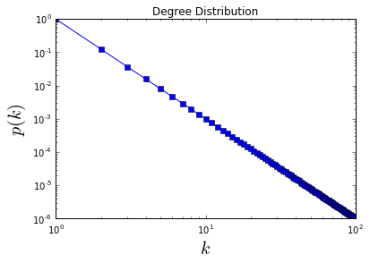

```python
%matplotlib inline

import matplotlib.pyplot as plt
x = range(1, 100)
y = [i**-3 for i in x]
plt.plot(x, y, 'b-s')
plt.ylabel('$p(k)$', fontsize = 20)
plt.xlabel('$k$', fontsize = 20)
plt.xscale('log')
plt.yscale('log')
plt.title('Degree Distribution')
plt.show()
```

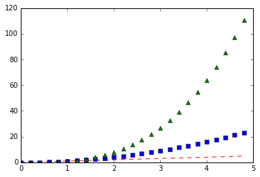

```python
import numpy as np
# red dashes, blue squares and green triangles
t = np.arange(0., 5., 0.2)
plt.plot(t, t, 'r--')
plt.plot(t, t**2, 'bs')
plt.plot(t, t**3, 'g^')
plt.show()
```

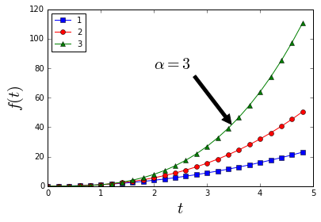

```python
# red dashes, blue squares and green triangles
t = np.arange(0., 5., 0.2)
plt.plot(t, t**2, 'b-s', label = '1')
plt.plot(t, t**2.5, 'r-o', label = '2')
plt.plot(t, t**3, 'g-^', label = '3')
plt.annotate(r'$\alpha = 3$', xy=(3.5, 40), xytext=(2, 80),
            arrowprops=dict(facecolor='black', shrink=0.05),
            fontsize = 20)
plt.ylabel('$f(t)$', fontsize = 20)
plt.xlabel('$t$', fontsize = 20)
plt.legend(loc=2,numpoints=1,fontsize=10)
plt.show()
# plt.savefig('/Users/chengjun/GitHub/cjc/figure/save_figure.png',
#             dpi = 300, bbox_inches="tight",transparent = True)
```

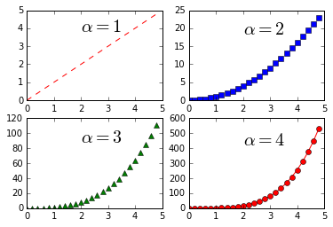

```python
plt.figure(1)
plt.subplot(221)
plt.plot(t, t, 'r--')
plt.text(2, 0.8*np.max(t), r'$\alpha = 1$', fontsize = 20)
plt.subplot(222)
plt.plot(t, t**2, 'bs')
plt.text(2, 0.8*np.max(t**2), r'$\alpha = 2$', fontsize = 20)
plt.subplot(223)
plt.plot(t, t**3, 'g^')
plt.text(2, 0.8*np.max(t**3), r'$\alpha = 3$', fontsize = 20)
plt.subplot(224)
plt.plot(t, t**4, 'r-o')
plt.text(2, 0.8*np.max(t**4), r'$\alpha = 4$', fontsize = 20)
plt.show()
```

```python
def f(t):
    return np.exp(-t) * np.cos(2*np.pi*t)

t1 = np.arange(0.0, 5.0, 0.1)
t2 = np.arange(0.0, 5.0, 0.02)
```

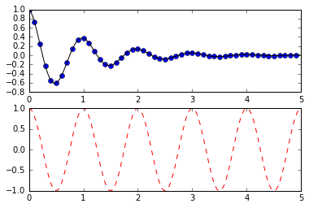

```python
plt.figure(1)
plt.subplot(211)
plt.plot(t1, f(t1), 'bo')
plt.plot(t2, f(t2), 'k')

plt.subplot(212)
plt.plot(t2, np.cos(2*np.pi*t2), 'r--')
plt.show()
```

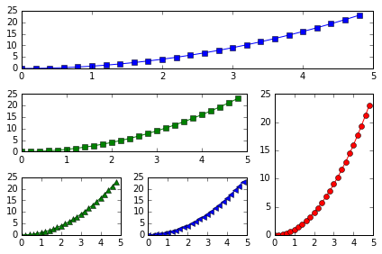

```python
import matplotlib.gridspec as gridspec
import numpy as np

t = np.arange(0., 5., 0.2)

gs = gridspec.GridSpec(3, 3)
ax1 = plt.subplot(gs[0, :])
plt.plot(t, t**2, 'b-s')
ax2 = plt.subplot(gs[1,:-1])
plt.plot(t, t**2, 'g-s')
ax3 = plt.subplot(gs[1:, -1])
plt.plot(t, t**2, 'r-o')
ax4 = plt.subplot(gs[-1,0])
plt.plot(t, t**2, 'g-^')
ax5 = plt.subplot(gs[-1,1])
plt.plot(t, t**2, 'b-<')
plt.tight_layout()
```

```python
def OLSRegressPlot(x,y,col,xlab,ylab):
    xx = sm.add_constant(x, prepend=True)
    res = sm.OLS(y,xx).fit()
    constant, beta = res.params
    r2 = res.rsquared
    lab = r'$\beta = %.2f, \,R^2 = %.2f$' %(beta,r2)
    plt.scatter(x,y,s=60,facecolors='none', edgecolors=col)
    plt.plot(x,constant + x*beta,"red",label=lab)
    plt.legend(loc = 'upper left',fontsize=16)
    plt.xlabel(xlab,fontsize=26)
    plt.ylabel(ylab,fontsize=26)
```

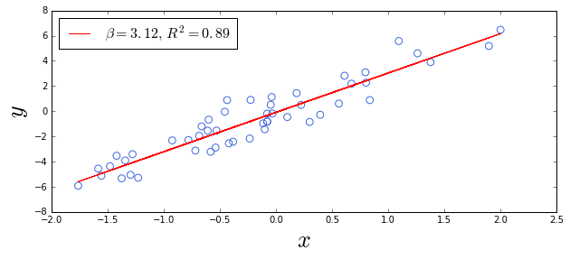

```python
x = np.random.randn(50)
y = np.random.randn(50) + 3*x
pearsonr(x, y)
fig = plt.figure(figsize=(10, 4),facecolor='white')
OLSRegressPlot(x,y,'RoyalBlue',r'$x$',r'$y$')
plt.show()
```

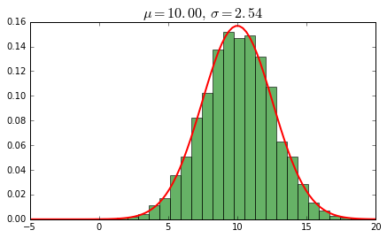

```python
fig = plt.figure(figsize=(7, 4),facecolor='white')
data = norm.rvs(10.0, 2.5, size=5000)
mu, std = norm.fit(data)
plt.hist(data, bins=25, normed=True, alpha=0.6, color='g')
xmin, xmax = plt.xlim()
x = np.linspace(xmin, xmax, 100)
p = norm.pdf(x, mu, std)
plt.plot(x, p, 'r', linewidth=2)
title = r"$\mu = %.2f, \,  \sigma = %.2f$" % (mu, std)
plt.title(title,size=16)
plt.show()
```

```python
from matplotlib.dates import WeekdayLocator, DayLocator, MONDAY, DateFormatter
from matplotlib.finance import quotes_historical_yahoo_ochl, candlestick_ochl

date1 = (2014, 2, 1)
date2 = (2014, 5, 1)
quotes = quotes_historical_yahoo_ochl('INTC', date1, date2)
```

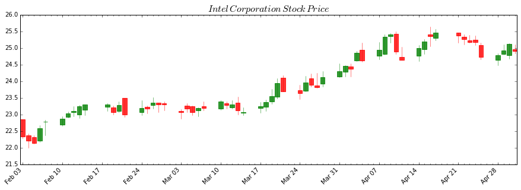

```python
fig = plt.figure(figsize=(15, 5))
ax = fig.add_subplot(1,1,1)
candlestick_ochl(ax, quotes, width=0.8, colorup='green', colordown='r', alpha=0.8)
mondays = WeekdayLocator(MONDAY)    # major ticks on the mondays
alldays = DayLocator()              # minor ticks on the days
weekFormatter = DateFormatter('%b %d')  # e.g., Jan 12
ax.xaxis.set_major_locator(mondays)
ax.xaxis.set_minor_locator(alldays)
ax.xaxis.set_major_formatter(weekFormatter)
ax.autoscale_view()
plt.setp( plt.gca().get_xticklabels(), rotation=45, horizontalalignment='right')
plt.title(r'$Intel \,Corporation \,Stock \,Price$',size=16)
fig.subplots_adjust(bottom=0.2)
plt.show()
```

```python
import pandas as pd
df = pd.read_csv('../data/data_write_to_file.txt', sep = '\t', names = ['a', 'b', 'c'])
df[:5]
```

|  | a | b | c |
| --- | --- | --- | --- |
| 0 | 0 | 0 | 0 |
| 1 | 1 | 1 | 1 |
| 2 | 2 | 4 | 8 |
| 3 | 3 | 9 | 27 |
| 4 | 4 | 16 | 64 |

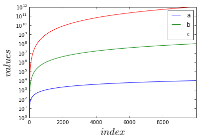

```python
df.plot.line()
plt.yscale('log')
plt.ylabel('$values$', fontsize = 20)
plt.xlabel('$index$', fontsize = 20)
plt.show()
```

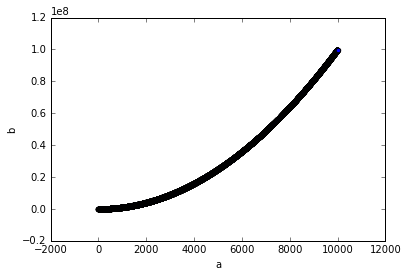

```python
df.plot.scatter(x='a', y='b')
plt.show()
```

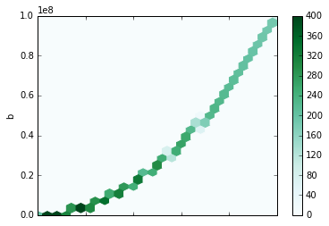

```python
df.plot.hexbin(x='a', y='b', gridsize=25)
plt.show()
```

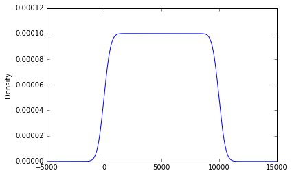

```python
df['a'].plot.kde()
plt.show()
```

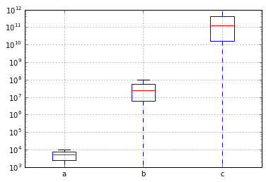

```python
bp = df.boxplot()
plt.yscale('log')
plt.show()
```

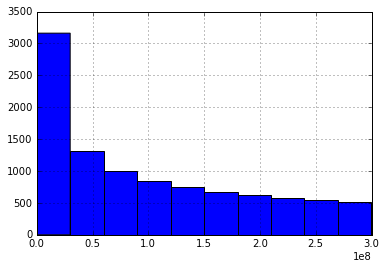

```python
df['c'].diff().hist()
plt.show()
```

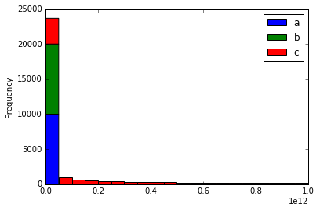

```python
df.plot.hist(stacked=True, bins=20)
# plt.yscale('log')
plt.show()
```

> To be a programmer is to develop a carefully managed relationship with error. There's no getting around it. You either make your accommodations with failure, or the work will become intolerable.

Ellen Ullman （an American computer programmer and author）

[figure not shown]

# This is the end.

> Thank you for your attention.